# WSW Study 3: How many participants do we need to have enough power to find a US valence x Task interaction effect on evaluative ratings?

- Show All Code
- Hide All Code
- View Source

Author

Jérémy Béna

Date

February 18, 2025

**Display R code**

```r
#Load (or install and load) packages
if (!require("pacman")) install.packages("pacman")
p_load('jsonlite', 'tidyverse', 'psych', 'papaja', 'kableExtra', 'afex', 'emmeans', 'effectsize', 'Superpower', 'gt', 'ggstatsplot')

set_sum_contrasts()

#read data files
read_file('data/pilot2_age.txt')%>%
#... split it into lines ...
 str_split('\n') %>% first() %>%
#... filter empty rows ...
 discard(function(x) x == '') %>%
#... parse JSON into a data.frame
 map_dfr(fromJSON, flatten=T) -> dat_age

read_file('data/pilot2_val.txt')%>%
#... split it into lines ...
 str_split('\n') %>% first() %>%
#... filter empty rows ...
 discard(function(x) x == '') %>%
#... parse JSON into a data.frame
 map_dfr(fromJSON, flatten=T) -> dat_val

#arrange
dat = full_join(dat_age, dat_val)

dat$url.srid = as.factor(dat$url.srid)
dat$us_valence = as.factor(dat$us_valence)
dat$reco_resp = as.factor(dat$reco_resp)

dat = dat %>%
   fill(url.srid, .direction = "down") %>%
  group_by(url.srid) %>%
  fill(consent, comment_study,pay_attention,serious, instructions_conditioning, '-0','-1','-2','-3','-4','-5','-6', .direction = "down") %>%
  fill(consent, comment_study, pay_attention,serious,instructions_conditioning,'-0','-1','-2','-3','-4','-5','-6', .direction = "up") %>%
  select(url.srid, sender, consent, duration, ended_on, pay_attention, serious, response, response_action
      #general information
         , '-0','-1','-2','-3','-4','-5','-6',comment_study,count_trial_learning, cs, us, us_valence, us_age, uss, resp_pos_learning #learning phase
         , count_trial_memory, idtarg, reco_resp, source_mem  #memory phase
         , count_trial_ratings, cs_rating #rating phase
         , instructions_conditioning
          )

dat$sports <- ifelse(dat$'-1'==TRUE|
                       dat$'-2'==TRUE|
                       dat$'-3'==TRUE|
                       dat$'-4'==TRUE|
                       dat$'-5'==TRUE|
                       dat$'-0'==TRUE|
                       dat$'-6'==TRUE,0,1)

#exclude
dat = dat %>% filter(sports == 1 & pay_attention == 1 & serious == 1)
```

# Added scenario in version 2 (18 February)

Update on 18 February: added Scenario 2b, which is Scenario 2 with $\alpha$ = .10 (instead of .05) and $1 - \beta$ = .9 (instead of .8). In this scenario, we would need *n* = 52 in each learning instructions condition.

# This document

I first present the target 2 (US valence) $\times$ 2 (Learning instructions) mixed ANOVA on mean evaluative ratings and correlations between repeated measures within each Learning instructions condition. I then present power analyses in four scenarios to plan for sample size to detect (1) a US valence $\times$ Learning instructions interaction (larger EC effect in the valence focus than in the age focus condition) and (2) a simple effect of US valence in the valence focus condition. Note that these estimates may be conservative, as I used an $\alpha$ level of .05 in all analyses (I did not adapt the $\alpha$ level for one-sided tests).

# Summary

If the interaction is exactly the one found in Pilot study 2 (with identical means, sds, and correlations; Scenario 1), we would need a total of 50 participants. If we have reasons to suspect a smaller interaction (Scenarios 2 and 3), we would need up to a total of 264 participants (Scenario 3; Scenario 2 is less pessimistic with a total of 96 participants). If we expect smaller (but still positive) correlations between mean evaluative ratings within each Learning instructions condition, we may need too many participants, too (Scenario 4).

# Calculate means and sds in each US Valence $\times$ Learning instructions cell

**Display R code**

```r
ratings = subset(dat,sender == "rating_trial")

ratings$cs_rating = as.numeric(ratings$cs_rating)
ratings$us_age[is.na(ratings$us_age)] = "dist"
ratings = ratings %>% mutate(cs_sex = ifelse(grepl("m_m", cs), "male", "female"))

ratings_cs = ratings %>% filter(us_valence!="dist") %>% droplevels()

rat = ratings_cs %>% group_by(url.srid, us_valence, instructions_conditioning) %>%
  summarize(mean_rating = mean(cs_rating))

rat_agg = describeBy(rat$mean_rating, list(rat$us_valence, rat$instructions_conditioning), mat = TRUE)

gt(describeBy(rat$mean_rating, list(rat$us_valence, rat$instructions_conditioning), mat = TRUE, digits = 2), caption = "Descriptive statistics of mean evaluative ratings as a function of US valence ('group1') and Learning instructions ('group2')")
```

Descriptive statistics of mean evaluative ratings as a function of US valence ('group1') and Learning instructions ('group2')

| item | group1 | group2 | vars | n | mean | sd | median | trimmed | mad | min | max | range | skew | kurtosis | se |
| --- | --- | --- | --- | --- | --- | --- | --- | --- | --- | --- | --- | --- | --- | --- | --- |
| 1 | negative | age_task | 1 | 28 | 4.54 | 0.64 | 4.46 | 4.55 | 0.62 | 2.92 | 5.75 | 2.83 | -0.08 | -0.15 | 0.12 |
| 2 | positive | age_task | 1 | 28 | 4.66 | 0.62 | 4.83 | 4.72 | 0.43 | 2.83 | 5.58 | 2.75 | -1.09 | 0.87 | 0.12 |
| 3 | negative | val_task | 1 | 32 | 4.40 | 1.04 | 4.17 | 4.34 | 0.93 | 2.50 | 7.00 | 4.50 | 0.48 | -0.26 | 0.18 |
| 4 | positive | val_task | 1 | 32 | 5.07 | 0.98 | 5.25 | 5.06 | 0.86 | 1.92 | 7.33 | 5.42 | -0.51 | 1.94 | 0.17 |

# Check the interaction in a $2 \times 2$ mixed ANOVA on mean evaluative ratings

**Display R code**

```r
mod1 = aov_ez(data=rat
       ,id="url.srid"
       ,dv="mean_rating"
       ,within ="us_valence"
       ,between="instructions_conditioning"
       )

p_mod1 = apa_print(mod1, es = "pes")

s_eff = pairs(emmeans(mod1,~us_valence|instructions_conditioning))

p_s_eff = apa_print(s_eff)
```

The US valence $\times$ Learning instructions interaction was significant, $F(1, 58) = 9.58$, $p = .003$, $\hat{\eta}^2_p = .142$. The EC effect (neg-pos) was significant in the Valence focus condition, $\Delta M = -0.68$, 95% CI $[-0.92, -0.43]$, $t(58) = -5.53$, $p < .001$ but not in the Age focus condition, $\Delta M = -0.12$, 95% CI $[-0.38, 0.14]$, $t(58) = -0.93$, $p = .355$ (see Fig. below).

**Display R code**

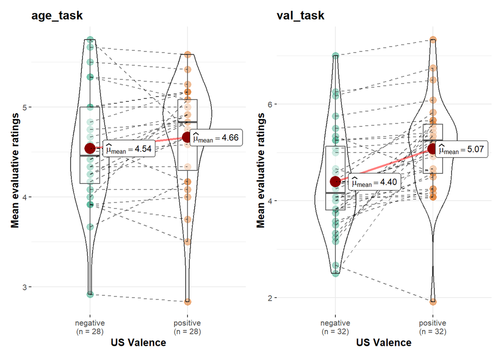

Mean evaluative ratings as a function of US valence and Learning instructions

```r
grouped_ggwithinstats(data = rat
    , x = us_valence
    , grouping.var = instructions_conditioning
    , y = mean_rating,
    , xlab = "US Valence",
    , ylab = "Mean evaluative ratings"
    , results.subtitle = FALSE
)
```

# Correlations between mean evaluative ratings for CS paired with US+ vs. US- in each Learning instructions condition

**Display R code**

```r
rat_age = rat %>% filter(instructions_conditioning=="age_task")
p_ca = apa_print(cor.test(rat_age$mean_rating[rat_age$us_valence=="positive"], rat_age$mean_rating[rat_age$us_valence=="negative"]))

rat_val = rat %>% filter(instructions_conditioning=="val_task")
p_cv = apa_print(cor.test(rat_val$mean_rating[rat_val$us_valence=="positive"], rat_val$mean_rating[rat_val$us_valence=="negative"]))
```

Mean evaluative ratings for CS paired with US+ and US- were positively associated in each Learning instructions condition (valence focus: $r = .63$, 95% CI $[.36, .80]$; age focus: $r = .80$, 95% CI $[.61, .90]$).

# Four scenarios for the power analyses: From quite optimistic to less so

Find required *n* (per Learning instructions condition) to have enough statistical power ($1-\beta = .8$) to detect the US valence $\times$ Learning instructions interaction on mean evaluative ratings (+ the EC effect in the valence focus condition) in four scenarios:

- **Scenario 1:** Exact means, SDs, and correlations as in Pilot Study 2
- **Scenario 2:** Scenario 1 but increase (reduce) the EC effect in the age (valence) focus condition to reduce the interaction effect (+ scenario 2b, with $\alpha$ = .1 and $1 - \beta$ = .9)
- **Scenario 3:** Scenario 2 but reduce the interaction effect even more
- **Scenario 4:** Scenario 2 but reduce correlations to $r = .5$

Additional scenarios (negative and null correlations between repeated measures) are considered in the “Additional analyses” section.

Analyses were conducted with at least $n =$ 10 and maximum $n =$ 150 in each Learning instructions condition.

## Scenario 1: Exact means, SDs, and correlations as in Pilot Study 2

**Display R code**

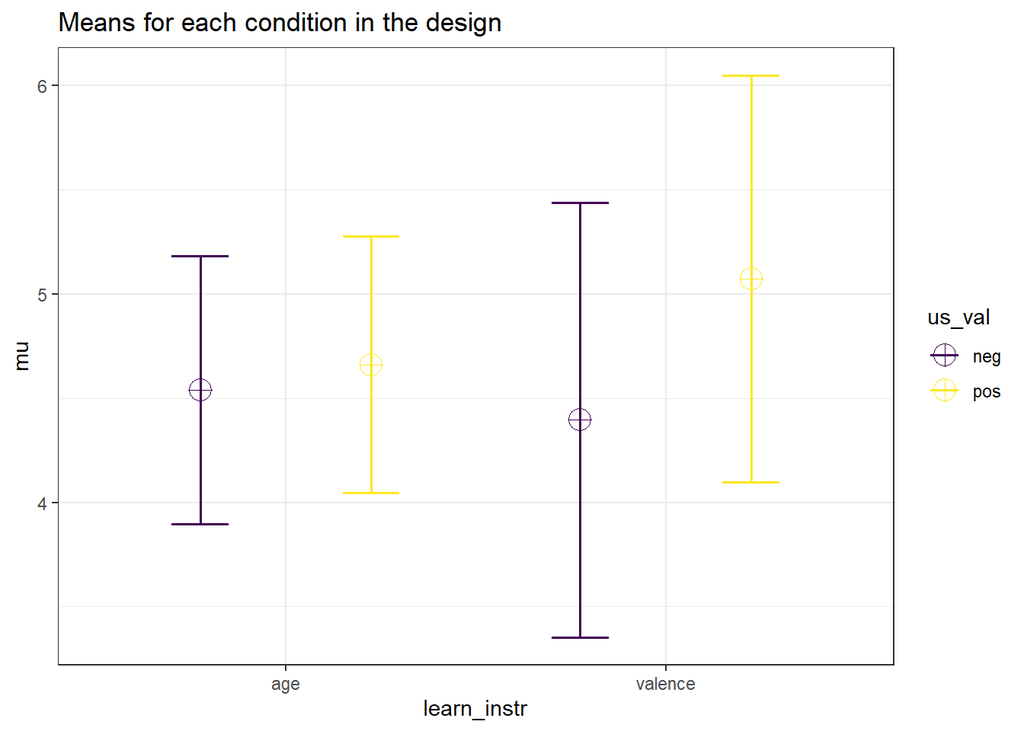

```r
n = 50 #just to generate the anova design

r_age = cor(rat_age$mean_rating[rat_age$us_valence=="positive"],rat_age$mean_rating[rat_age$us_valence=="negative"]) #correlation between ratings on CS paired with US+ and US- in the age condition

r_val = cor(rat_val$mean_rating[rat_val$us_valence=="positive"], rat_val$mean_rating[rat_val$us_valence=="negative"]) #correlation between ratings on CS paired with US+ and US- in the valence condition

r_mat = matrix(c(1,r_age,0,0
         ,r_age,1,0,0
         ,0,0,1,r_val
         ,0,0,r_val,1), nrow=4) #use values from the correlations calculated above

design_exp = ANOVA_design(design = "2b*2w"
                          ,label_list = c("learn_instr"
                                          , "age", "valence"
                                          ,"us_val"
                                          ,"neg", "pos")
                           ,n = n
                           ,mu = c(rat_agg$mean[1], rat_agg$mean[2], rat_agg$mean[3], rat_agg$mean[4])
                           ,sd = c(rat_agg$sd[1], rat_agg$sd[2], rat_agg$sd[3], rat_agg$sd[4])
                           ,r=r_mat
                           ,plot = TRUE)
```

**Display R code**

```r
n_min = 10
n_max = 150
pwr = .8
a_lev = .05

#Find statistical power for a range of sample sizes
power_design1 = plot_power(design_exp
                          ,min_n = n_min
                          ,max_n = n_max
                          ,desired_power = pwr*100
                          ,emm = TRUE
                          ,emm_comp = "us_val|learn_instr"
                          ,alpha_level = a_lev
                          ,plot = FALSE
                          ,verbose = FALSE)

#power_design1$plot_emm

gt(power_design1$anova_n,caption = "Power analysis for the ANOVA -- Scenario 1")
```

Power analysis for the ANOVA -- Scenario 1

| variable | label | n | achieved_power | desired_power |
| --- | --- | --- | --- | --- |
| learn_instr | Desired Power Not Reached | 150 | 32.61707 | 80 |
| us_val | Desired Power Achieved | 13 | 82.20972 | 80 |
| learn_instr:us_val | Desired Power Achieved | 25 | 80.96693 | 80 |

**Display R code**

```r
gt(power_design1$effect_sizes,caption = "Effect sizes in the ANOVA -- Scenario 1")
```

Effect sizes in the ANOVA -- Scenario 1

| partial_eta_squared | cohen_f |
| --- | --- |
| 0.007629251 | 0.08768069 |
| 0.259125257 | 0.59140158 |
| 0.144382258 | 0.41078732 |

**Display R code**

```r
gt(power_design1$emm_n,caption = "Power analysis for the post hoc analyses -- Scenario 1")
```

Power analysis for the post hoc analyses -- Scenario 1

| variable | label | n | achieved_power | desired_power |
| --- | --- | --- | --- | --- |
| us_val_neg - us_val_pos | Desired Power Not Reached | 150 | 59.39224 | 80 |
| NA | Desired Power Achieved | 10 | 84.76362 | 80 |

**Display R code**

```r
gt(power_design1$effect_sizes_emm,caption = "Effect sizes of the EC effects -- Scenario 1")
```

Effect sizes of the EC effects -- Scenario 1

| contrast | learn_instr | partial_eta_squared | cohen_f |
| --- | --- | --- | --- |
| us_val_neg - us_val_pos | learn_instr_age | 0.01604898 | 0.1277136 |
| us_val_neg - us_val_pos | learn_instr_valence | 0.33430582 | 0.7086546 |

In **Scenario 1**, we would need at least **25 participants in each Learning instructions condition** ($N_{total}$ = 50) to have enough power ($1-\beta$ = 0.8; calculated: 0.81) to find the interaction (estimated to be $\eta^2_p$ $\approx$ 0.144).

This sample size provides enough power to find an EC effect of $\eta^2_p$ $\approx$ 0.334 in the **Valence** focus condition, as $1 - \beta$ = 0.85 to find this effect is achieved with $n$ = 10.

Regarding the EC effect in the **Age** focus condition, $n$ = 150 is not enough to detect it ($1-\beta$ = 0.59; $\eta^2_p$ $\approx$ 0.016).

## Scenario 2: Scenario 1 but reduce the interaction effect

I tried to reduce the interaction term without affecting much main effects. I increased the EC effect in the age focus condition and reduced it in the valence focus condition to calculate power to detect both a smaller interaction and a smaller EC effect in the valence focus condition.

**Display R code**

```r
n = 50 #just to generate the anova design

r_age = cor(rat_age$mean_rating[rat_age$us_valence=="positive"],rat_age$mean_rating[rat_age$us_valence=="negative"]) #correlation between ratings on CS paired with US+ and US- in the age condition

r_val = cor(rat_val$mean_rating[rat_val$us_valence=="positive"], rat_val$mean_rating[rat_val$us_valence=="negative"]) #correlation between ratings on CS paired with US+ and US- in the valence condition

reduce_inter = .04 #changes EC effects by .08; reduces interaction by .16

r_mat = matrix(c(1,r_age,0,0
         ,r_age,1,0,0
         ,0,0,1,r_val
         ,0,0,r_val,1), nrow=4) #use values from the correlations calculated above

design_exp2 = ANOVA_design(design = "2b*2w"
                          ,label_list = c("learn_instr"
                                          , "age", "valence"
                                          ,"us_val"
                                          ,"neg", "pos")
                           ,n = n
                           ,mu = c(rat_agg$mean[1]-reduce_inter, rat_agg$mean[2]+reduce_inter, rat_agg$mean[3]+reduce_inter, rat_agg$mean[4]-reduce_inter)
                           ,sd = c(rat_agg$sd[1], rat_agg$sd[2], rat_agg$sd[3], rat_agg$sd[4])
                           ,r=r_mat
                           ,plot = TRUE)
```

**Display R code**

```r
n_min = 10
n_max = 150
pwr = .8
a_lev = .05

#Find statistical power for a range of sample sizes
power_design2 = plot_power(design_exp2
                          ,min_n = n_min
                          ,max_n = n_max
                          ,desired_power = pwr*100
                          ,emm = TRUE
                          ,emm_comp = "us_val|learn_instr"
                          ,alpha_level = a_lev
                          ,plot = FALSE
                          ,verbose = FALSE)

#power_design2$plot_emm

gt(power_design2$anova_n,caption = "Power analysis for the ANOVA -- Scenario 2")
```

Power analysis for the ANOVA -- Scenario 2

| variable | label | n | achieved_power | desired_power |
| --- | --- | --- | --- | --- |
| learn_instr | Desired Power Not Reached | 150 | 32.61707 | 80 |
| us_val | Desired Power Achieved | 13 | 82.20972 | 80 |
| learn_instr:us_val | Desired Power Achieved | 48 | 80.67184 | 80 |

**Display R code**

```r
gt(power_design2$effect_sizes,caption = "Effect sizes in the ANOVA -- Scenario 2")
```

Effect sizes in the ANOVA -- Scenario 2

| partial_eta_squared | cohen_f |
| --- | --- |
| 0.007629251 | 0.08768069 |
| 0.259125257 | 0.59140158 |
| 0.078751160 | 0.29237484 |

**Display R code**

```r
gt(power_design2$emm_n,caption = "Power analysis for the post hoc analyses -- Scenario 2")
```

Power analysis for the post hoc analyses -- Scenario 2

| variable | label | n | achieved_power | desired_power |
| --- | --- | --- | --- | --- |
| us_val_neg - us_val_pos | Desired Power Achieved | 90 | 80.29202 | 80 |
| NA | Desired Power Achieved | 12 | 83.04078 | 80 |

**Display R code**

```r
gt(power_design2$effect_sizes_emm,caption = "Effect sizes of the EC effects -- Scenario 2")
```

Effect sizes of the EC effects -- Scenario 2

| contrast | learn_instr | partial_eta_squared | cohen_f |
| --- | --- | --- | --- |
| us_val_neg - us_val_pos | learn_instr_age | 0.04279519 | 0.2114438 |
| us_val_neg - us_val_pos | learn_instr_valence | 0.28084994 | 0.6249243 |

In **Scenario 2**, we would need at least **48 participants in each Learning instructions condition** ($N_{total}$ = 96) to have enough power ($1-\beta$ = 0.8; calculated: 0.81) to find the interaction (estimated to be $\eta^2_p$ $\approx$ 0.079).

This sample size provides enough power to find an EC effect of $\eta^2_p$ $\approx$ 0.281 in the **Valence** focus condition, as $1 - \beta$ = 0.83 to find this effect is achieved with $n$ = 12.

Regarding the EC effect in the **Age** focus condition, $n$ = 90 is needed to detect it ($1-\beta$ = 0.8; $\eta^2_p$ $\approx$ 0.043).

## Scenario 2b: Scenario 2 but alpha level = .1 and power = .9

**Display R code**

```r
n = 50 #just to generate the anova design

r_age = cor(rat_age$mean_rating[rat_age$us_valence=="positive"],rat_age$mean_rating[rat_age$us_valence=="negative"]) #correlation between ratings on CS paired with US+ and US- in the age condition

r_val = cor(rat_val$mean_rating[rat_val$us_valence=="positive"], rat_val$mean_rating[rat_val$us_valence=="negative"]) #correlation between ratings on CS paired with US+ and US- in the valence condition

reduce_inter = .04 #changes EC effects by .08; reduces interaction by .16

r_mat = matrix(c(1,r_age,0,0
         ,r_age,1,0,0
         ,0,0,1,r_val
         ,0,0,r_val,1), nrow=4) #use values from the correlations calculated above

design_exp2b = ANOVA_design(design = "2b*2w"
                          ,label_list = c("learn_instr"
                                          , "age", "valence"
                                          ,"us_val"
                                          ,"neg", "pos")
                           ,n = n
                           ,mu = c(rat_agg$mean[1]-reduce_inter, rat_agg$mean[2]+reduce_inter, rat_agg$mean[3]+reduce_inter, rat_agg$mean[4]-reduce_inter)
                           ,sd = c(rat_agg$sd[1], rat_agg$sd[2], rat_agg$sd[3], rat_agg$sd[4])
                           ,r=r_mat
                           ,plot = TRUE)
```

**Display R code**

```r
n_min = 10
n_max = 150
pwr = .9
a_lev = .1

#Find statistical power for a range of sample sizes
power_design2b = plot_power(design_exp2b
                          ,min_n = n_min
                          ,max_n = n_max
                          ,desired_power = pwr*100
                          ,emm = TRUE
                          ,emm_comp = "us_val|learn_instr"
                          ,alpha_level = a_lev
                          ,plot = FALSE
                          ,verbose = FALSE)

#power_design2$plot_emm

gt(power_design2b$anova_n,caption = "Power analysis for the ANOVA -- Scenario 2")
```

Power analysis for the ANOVA -- Scenario 2

| variable | label | n | achieved_power | desired_power |
| --- | --- | --- | --- | --- |
| learn_instr | Desired Power Not Reached | 150 | 44.72321 | 90 |
| us_val | Desired Power Achieved | 14 | 91.79434 | 90 |
| learn_instr:us_val | Desired Power Achieved | 52 | 90.44025 | 90 |

**Display R code**

```r
gt(power_design2b$effect_sizes,caption = "Effect sizes in the ANOVA -- Scenario 2")
```

Effect sizes in the ANOVA -- Scenario 2

| partial_eta_squared | cohen_f |
| --- | --- |
| 0.007629251 | 0.08768069 |
| 0.259125257 | 0.59140158 |
| 0.078751160 | 0.29237484 |

**Display R code**

```r
gt(power_design2b$emm_n,caption = "Power analysis for the post hoc analyses -- Scenario 2")
```

Power analysis for the post hoc analyses -- Scenario 2

| variable | label | n | achieved_power | desired_power |
| --- | --- | --- | --- | --- |
| us_val_neg - us_val_pos | Desired Power Achieved | 98 | 90.23704 | 90 |
| NA | Desired Power Achieved | 12 | 90.49919 | 90 |

**Display R code**

```r
gt(power_design2b$effect_sizes_emm,caption = "Effect sizes of the EC effects -- Scenario 2")
```

Effect sizes of the EC effects -- Scenario 2

| contrast | learn_instr | partial_eta_squared | cohen_f |
| --- | --- | --- | --- |
| us_val_neg - us_val_pos | learn_instr_age | 0.04279519 | 0.2114438 |
| us_val_neg - us_val_pos | learn_instr_valence | 0.28084994 | 0.6249243 |

In **Scenario 2b** (which is Scenario 2 but with $\alpha$ level = .10 instead of .05 and $1 - \beta$ = .9 instead of .8), we would need at least **52 participants in each Learning instructions condition** ($N_{total}$ = 104) to have enough power ($1-\beta$ = 0.9; calculated: 0.9) to find the interaction (estimated to be $\eta^2_p$ $\approx$ 0.079).

This sample size provides enough power to find an EC effect of $\eta^2_p$ $\approx$ 0.281 in the **Valence** focus condition, as $1 - \beta$ = 0.9 to find this effect is achieved with $n$ = 12.

Regarding the EC effect in the **Age** focus condition, $n$ = 98 is needed to detect it ($1-\beta$ = 0.9; $\eta^2_p$ $\approx$ 0.043).

## Scenario 3: Scenario 2 but reduce the interaction effect even more

**Display R code**

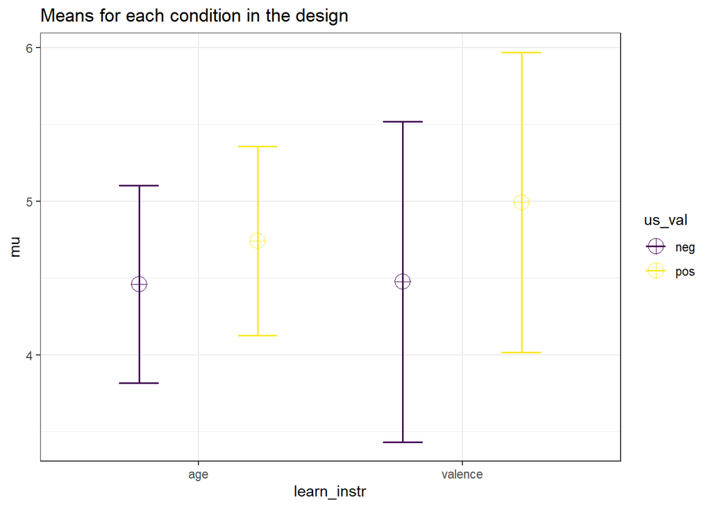

```r
n = 50 #just to generate the anova design

r_age = cor(rat_age$mean_rating[rat_age$us_valence=="positive"],rat_age$mean_rating[rat_age$us_valence=="negative"]) #correlation between ratings on CS paired with US+ and US- in the age condition

r_val = cor(rat_val$mean_rating[rat_val$us_valence=="positive"], rat_val$mean_rating[rat_val$us_valence=="negative"]) #correlation between ratings on CS paired with US+ and US- in the valence condition

reduce_inter2 = .08 #changes EC effects by .16; reduces interaction by .32

r_mat = matrix(c(1,r_age,0,0
         ,r_age,1,0,0
         ,0,0,1,r_val
         ,0,0,r_val,1), nrow=4) #use values from the correlations calculated above

design_exp3 = ANOVA_design(design = "2b*2w"
                          ,label_list = c("learn_instr"
                                          , "age", "valence"
                                          ,"us_val"
                                          ,"neg", "pos")
                           ,n = n
                           ,mu =c(rat_agg$mean[1]-reduce_inter2, rat_agg$mean[2]+reduce_inter2, rat_agg$mean[3]+reduce_inter2, rat_agg$mean[4]-reduce_inter2)
                           ,sd = c(rat_agg$sd[1], rat_agg$sd[2], rat_agg$sd[3], rat_agg$sd[4])
                           ,r=r_mat
                           ,plot = TRUE)
```

**Display R code**

```r
n_min = 10
n_max = 150
pwr = .8
a_lev = .05

#Find statistical power for a range of sample sizes
power_design3 = plot_power(design_exp3
                          ,min_n = n_min
                          ,max_n = n_max
                          ,desired_power = pwr*100
                          ,emm = TRUE
                          ,emm_comp = "us_val|learn_instr"
                          ,alpha_level = a_lev
                          ,plot = FALSE
                          ,verbose = FALSE)

#power_design3$plot_emm

gt(power_design3$anova_n,caption = "Power analysis for the ANOVA -- Scenario 3")
```

Power analysis for the ANOVA -- Scenario 3

| variable | label | n | achieved_power | desired_power |
| --- | --- | --- | --- | --- |
| learn_instr | Desired Power Not Reached | 150 | 32.61707 | 80 |
| us_val | Desired Power Achieved | 13 | 82.20972 | 80 |
| learn_instr:us_val | Desired Power Achieved | 132 | 80.14509 | 80 |

**Display R code**

```r
gt(power_design3$effect_sizes,caption = "Effect sizes in the ANOVA -- Scenario 3")
```

Effect sizes in the ANOVA -- Scenario 3

| partial_eta_squared | cohen_f |
| --- | --- |
| 0.007629251 | 0.08768069 |
| 0.259125257 | 0.59140158 |
| 0.029373965 | 0.17396237 |

**Display R code**

```r
gt(power_design3$emm_n,caption = "Power analysis for the post hoc analyses -- Scenario 3")
```

Power analysis for the post hoc analyses -- Scenario 3

| variable | label | n | achieved_power | desired_power |
| --- | --- | --- | --- | --- |
| us_val_neg - us_val_pos | Desired Power Achieved | 47 | 80.57690 | 80 |
| NA | Desired Power Achieved | 15 | 81.37286 | 80 |

**Display R code**

```r
gt(power_design3$effect_sizes_emm,caption = "Effect sizes of the EC effects -- Scenario 3")
```

Effect sizes of the EC effects -- Scenario 3

| contrast | learn_instr | partial_eta_squared | cohen_f |
| --- | --- | --- | --- |
| us_val_neg - us_val_pos | learn_instr_age | 0.0801449 | 0.2951741 |
| us_val_neg - us_val_pos | learn_instr_valence | 0.2265396 | 0.5411940 |

In **Scenario 3**, we would need at least **132 participants in each Learning instructions condition** ($N_{total}$ = 264) to have enough power ($1-\beta$ = 0.8; calculated: 0.8) to find the interaction (estimated to be $\eta^2_p$ $\approx$ 0.029).

This sample size provides enough power to find an EC effect of $\eta^2_p$ $\approx$ 0.227 in the **Valence** focus condition, as $1 - \beta$ = 0.81 to find this effect is achieved with $n$ = 15.

Regarding the EC effect in the **Age** focus condition, $n$ = 47 is needed to detect it ($1-\beta$ = 0.81; $\eta^2_p$ $\approx$ 0.08).

## Scenario 4: Scenario 2 but r = .5

**Display R code**

```r
n = 50 #just to generate the anova design

r_age2 = .5
r_val2 = .5

reduce_inter3 = reduce_inter

r_mat2 = matrix(c(1,r_age2,0,0
         ,r_age2,1,0,0
         ,0,0,1,r_val2
         ,0,0,r_val2,1), nrow=4)

design_exp4 = ANOVA_design(design = "2b*2w"
                          ,label_list = c("learn_instr"
                                          , "age", "valence"
                                          ,"us_val"
                                          ,"neg", "pos")
                           ,n = n
                           ,mu = c(rat_agg$mean[1]-reduce_inter3, rat_agg$mean[2]+reduce_inter3, rat_agg$mean[3]+reduce_inter3, rat_agg$mean[4]-reduce_inter3)
                           ,sd = c(rat_agg$sd[1], rat_agg$sd[2], rat_agg$sd[3], rat_agg$sd[4])
                           ,r=r_mat2
                           ,plot = TRUE)
```

**Display R code**

```r
n_min = 10
n_max = 150
pwr = .8
a_lev = .05

#Find statistical power for a range of sample sizes
power_design4 = plot_power(design_exp4
                          ,min_n = n_min
                          ,max_n = n_max
                          ,desired_power = pwr*100
                          ,emm = TRUE
                          ,emm_comp = "learn_instr|us_val"
                          ,contrast_type = "pairwise"
                          ,alpha_level = a_lev
                          ,plot = FALSE
                          ,verbose = FALSE)

#power_design4$plot_emm

gt(power_design4$anova_n,caption = "Power analysis for the ANOVA -- Scenario 4")
```

Power analysis for the ANOVA -- Scenario 4

| variable | label | n | achieved_power | desired_power |
| --- | --- | --- | --- | --- |
| learn_instr | Desired Power Not Reached | 150 | 35.78154 | 80 |
| us_val | Desired Power Achieved | 19 | 81.17982 | 80 |
| learn_instr:us_val | Desired Power Achieved | 73 | 80.34151 | 80 |

**Display R code**

```r
gt(power_design4$effect_sizes,caption = "Effect sizes in the ANOVA -- Scenario 4")
```

Effect sizes in the ANOVA -- Scenario 4

| partial_eta_squared | cohen_f |
| --- | --- |
| 0.008520712 | 0.0927035 |
| 0.184601083 | 0.4758083 |
| 0.052431213 | 0.2352283 |

**Display R code**

```r
gt(power_design4$emm_n,caption = "Power analysis for the post hoc analyses -- Scenario 4")
```

Power analysis for the post hoc analyses -- Scenario 4

| variable | label | n | achieved_power | desired_power |
| --- | --- | --- | --- | --- |
| learn_instr_age - learn_instr_valence | Desired Power Not Reached | 150 | 9.600585 | 80 |
| NA | Desired Power Achieved | 96 | 80.087027 | 80 |

**Display R code**

```r
gt(power_design4$effect_sizes_emm,caption = "Effect sizes of the EC effects -- Scenario 4")
```

| contrast | us_val | partial_eta_squared | cohen_f |
| --- | --- | --- | --- |
| learn_instr_age - learn_instr_valence | us_val_neg | 0.00132298 | 0.03639688 |
| learn_instr_age - learn_instr_valence | us_val_pos | 0.03999965 | 0.20412321 |

In **Scenario 4**, we would need at least **73 participants in each Learning instructions condition** ($N_{total}$ = 146) to have enough power ($1-\beta$ = 0.8; calculated: 0.8) to find the interaction (estimated to be $\eta^2_p$ $\approx$ 0.052).

# Additional analyses

## If the correlations between repeated measures are negative or Zero?

### Additional scenario 1: Scenario 1 with r = -0.5

**Display R code**

```r
n = 50

r_age = -.5
r_val = -.5

r_mat = matrix(c(1,r_age,0,0
         ,r_age,1,0,0
         ,0,0,1,r_val
         ,0,0,r_val,1), nrow=4) #use values from the correlations calculated above

design_exp_add1 = ANOVA_design(design = "2b*2w"
                          ,label_list = c("learn_instr"
                                          , "age", "valence"
                                          ,"us_val"
                                          ,"neg", "pos")
                           ,n = n
                           ,mu = c(rat_agg$mean[1], rat_agg$mean[2], rat_agg$mean[3], rat_agg$mean[4])
                           ,sd = c(rat_agg$sd[1], rat_agg$sd[2], rat_agg$sd[3], rat_agg$sd[4])
                           ,r=r_mat
                           ,plot = FALSE)
```

**Display R code**

```r
n_min = 10
n_max = 150
pwr = .8
a_lev = .05

#Find statistical power for a range of sample sizes
power_design_add1 = plot_power(design_exp_add1
                          ,min_n = n_min
                          ,max_n = n_max
                          ,desired_power = pwr*100
                          ,emm = TRUE
                          ,emm_comp = "us_val|learn_instr"
                          ,alpha_level = a_lev
                          ,plot = FALSE
                          ,verbose = FALSE)

#power_design_add1$plot_emm

gt(power_design_add1$anova_n,caption = "Power analysis for the ANOVA -- Additional scenario 1")
```

Power analysis for the ANOVA -- Additional scenario 1

| variable | label | n | achieved_power | desired_power |
| --- | --- | --- | --- | --- |
| learn_instr | Desired Power Not Reached | 150 | 78.80308 | 80 |
| us_val | Desired Power Achieved | 54 | 80.58953 | 80 |
| learn_instr:us_val | Desired Power Achieved | 110 | 80.28126 | 80 |

**Display R code**

```r
gt(power_design_add1$effect_sizes,caption = "Effect sizes in the ANOVA -- Additional scenario 1")
```

Effect sizes in the ANOVA -- Additional scenario 1

| partial_eta_squared | cohen_f |
| --- | --- |
| 0.02507517 | 0.1603749 |
| 0.07032576 | 0.2750374 |
| 0.03521153 | 0.1910409 |

**Display R code**

```r
gt(power_design_add1$emm_n,caption = "Power analysis for the post hoc analyses -- Additional scenario 1")
```

Power analysis for the post hoc analyses -- Additional scenario 1

| variable | label | n | achieved_power | desired_power |
| --- | --- | --- | --- | --- |
| us_val_neg - us_val_pos | Desired Power Not Reached | 150 | 17.55651 | 80 |
| NA | Desired Power Achieved | 38 | 80.68094 | 80 |

**Display R code**

```r
gt(power_design_add1$effect_sizes_emm,caption = "Effect sizes of the EC effects -- Additional scenario 1")
```

Effect sizes of the EC effects -- Additional scenario 1

| contrast | learn_instr | partial_eta_squared | cohen_f |
| --- | --- | --- | --- |
| us_val_neg - us_val_pos | learn_instr_age | 0.003515308 | 0.05939452 |
| us_val_neg - us_val_pos | learn_instr_valence | 0.097973202 | 0.32956716 |

### Additional scenario 2: Scenario 1 with r = 0

**Display R code**

```r
n = 50

r_age = 0
r_val = 0

r_mat = matrix(c(1,r_age,0,0
         ,r_age,1,0,0
         ,0,0,1,r_val
         ,0,0,r_val,1), nrow=4) #use values from the correlations calculated above

design_exp_add2 = ANOVA_design(design = "2b*2w"
                          ,label_list = c("learn_instr"
                                          , "age", "valence"
                                          ,"us_val"
                                          ,"neg", "pos")
                           ,n = n
                           ,mu = c(rat_agg$mean[1], rat_agg$mean[2], rat_agg$mean[3], rat_agg$mean[4])
                           ,sd = c(rat_agg$sd[1], rat_agg$sd[2], rat_agg$sd[3], rat_agg$sd[4])
                           ,r=r_mat
                           ,plot = FALSE)
```

**Display R code**

```r
n_min = 10
n_max = 150
pwr = .8
a_lev = .05

#Find statistical power for a range of sample sizes
power_design_add2 = plot_power(design_exp_add2
                          ,min_n = n_min
                          ,max_n = n_max
                          ,desired_power = pwr*100
                          ,emm = TRUE
                          ,emm_comp = "us_val|learn_instr"
                          ,alpha_level = a_lev
                          ,plot = FALSE
                          ,verbose = FALSE)

#power_design_add1$plot_emm

gt(power_design_add2$anova_n,caption = "Power analysis for the ANOVA -- Additional scenario 2")
```

Power analysis for the ANOVA -- Additional scenario 2

| variable | label | n | achieved_power | desired_power |
| --- | --- | --- | --- | --- |
| learn_instr | Desired Power Not Reached | 150 | 49.72945 | 80 |
| us_val | Desired Power Achieved | 36 | 80.19595 | 80 |
| learn_instr:us_val | Desired Power Achieved | 74 | 80.43957 | 80 |

**Display R code**

```r
gt(power_design_add2$effect_sizes,caption = "Effect sizes in the ANOVA -- Additional scenario 2")
```

Effect sizes in the ANOVA -- Additional scenario 2

| partial_eta_squared | cohen_f |
| --- | --- |
| 0.01271931 | 0.1135041 |
| 0.10185049 | 0.3367497 |
| 0.05187399 | 0.2339062 |

**Display R code**

```r
gt(power_design_add2$emm_n,caption = "Power analysis for the post hoc analyses -- Additional scenario 2")
```

Power analysis for the post hoc analyses -- Additional scenario 2

| variable | label | n | achieved_power | desired_power |
| --- | --- | --- | --- | --- |
| us_val_neg - us_val_pos | Desired Power Not Reached | 150 | 23.99337 | 80 |
| NA | Desired Power Achieved | 26 | 81.16499 | 80 |

**Display R code**

```r
gt(power_design_add2$effect_sizes_emm,caption = "Effect sizes of the EC effects -- Additional scenario 2")
```

Effect sizes of the EC effects -- Additional scenario 2

| contrast | learn_instr | partial_eta_squared | cohen_f |
| --- | --- | --- | --- |
| us_val_neg - us_val_pos | learn_instr_age | 0.005260572 | 0.07272133 |
| us_val_neg - us_val_pos | learn_instr_valence | 0.140024705 | 0.40351469 |